# Predicting CO2 Emissions by Power Plant

3/10/2021

## The Big Picture

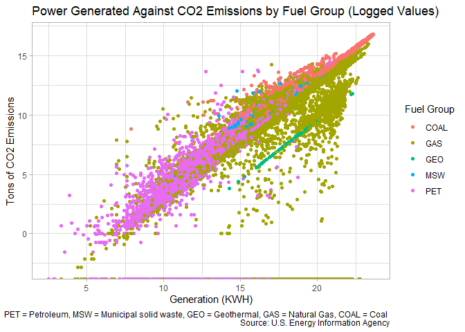

**- Question:** How much carbon dioxide will a power plant emit in a year?  
**- Relevance:** limiting atmospheric CO2 emissions to combat climate change.  
**- This is a prediction problem** because it concerns estimating CO2 emissions from a power plant as opposed to the relation between CO2 emissions and other variables.  
**- The outcome variable,** carbon dioxide emitted annually, is measured in tons.

## Data

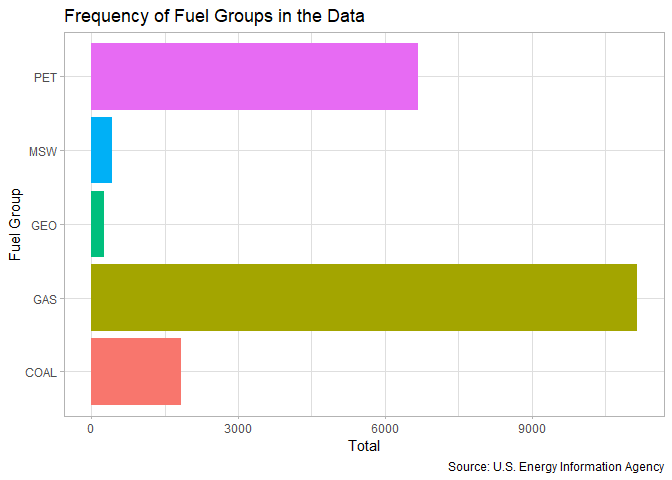

**- Annual data** from 2016 to 2019. **- Sources:** *U.S. Energy Information Agency* and *National Centers for Environmental Information*.  
**- Example variables:** kilowatt hour generation, Residential Energy Demand Temperature Index (REDTI), aggregated fuel group, and quantity of fuel consumed.  
**- Shortcomings:** annual emission timeframe, missing REDTI data for Hawaii and Alaska, and energy demand generalized by state.  
**- Data cleaning** involved binding multiple dataframes together and renaming variables with long names such as “fuel_consumption_for_useful_thermal_output_mmbtu”

## Methods

**Preparation:** used a tidymodels recipe that created dummy variables for all nominal predictors, computed mean imputation for all numerical predictors, removed all low-variance, highly correlated, and linearly depended variables, and normalized all predictors.

**Four methods**  
1. Linear Regression  
2. Elasticnet Regression  
3. Decision Tree  
4. Boosted Ensemble

**Tuning Method**  
**-** 5-fold Cross Validation  
**-** Root Mean Square Error

**Tuned Parameters**  
**-** Elasticnet Regression: *Penalty = 0.01, Mixture = 0.3*  
**-** Decision Tree: *Cost Complexity = 0, Tree Depth = 10*  
**-** Boosted Ensemble: *Learning Rate = 0.1, Tree Depth = 11*

## Outcome

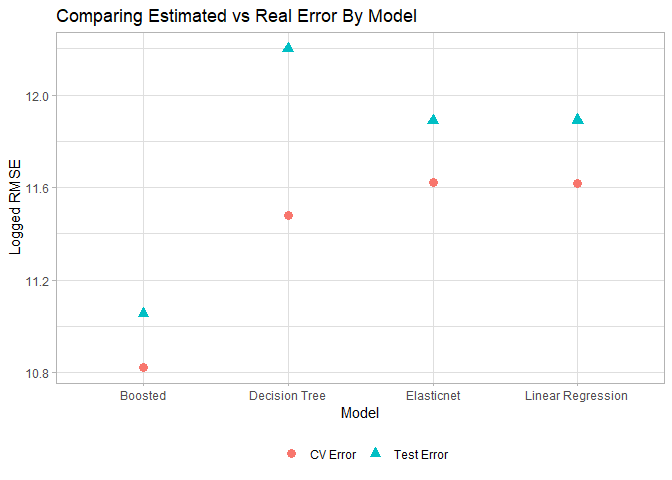

**-** The boosted model performed the best on CV and test data!

**-** The decision tree’s dramatic drop in performance is likely due to it being overfit to the training data.

**-** The elasticnet and regression models had similar errors on CV and test data; suggesting possibly similar models.

## Sources

- [Emissions by power plant for CO2, SO2, and NOx](https://www.eia.gov/electricity/data/emissions/)
- [Guide to data](https://www.eia.gov/electricity/data/guide/pdf/guide.pdf)
- [Energy demand and degree days data](https://www.ncdc.noaa.gov/societal-impacts/redti/time-series/USA/dec/year-to-date)

**Contact:** ojetton@uoregon.edu